# 시계열 분석1

2023-08-28

### 시계열 분석 라이브러리

- ts: 시계열 데이터 전처리 라이브러리
- tseries: 시계열 데이터 시각화 라이브러리
- TSA: 시계열 데이터셋이 내장된 라이브러리
- forecast: 시계열 예측 및 검정 라이브러리

```r
# library(forecast)
# library(TSA)
```

#### 시계열 데이터 만들기(ts 함수)

```r
ts(1:16, frequency = 4, start=c(2021, 1))
```

```
##      Qtr1 Qtr2 Qtr3 Qtr4
## 2021    1    2    3    4
## 2022    5    6    7    8
## 2023    9   10   11   12
## 2024   13   14   15   16
```

다음과 같이 써도 동일

```r
ts(1:16, f=4, s=c(2021, 1))
```

```
##      Qtr1 Qtr2 Qtr3 Qtr4
## 2021    1    2    3    4
## 2022    5    6    7    8
## 2023    9   10   11   12
## 2024   13   14   15   16
```

입력된 dataset으로 생성 가능

```r
dt_f <- matrix( c(100, 150, 200, 100,
                120, 180, 250, 300,
                  170, 400, 500, 250,
                201, 305, 170, 50))

ts(data=dt_f, f=4, s=c(2021, 1))
```

```
##      Qtr1 Qtr2 Qtr3 Qtr4
## 2021  100  150  200  100
## 2022  120  180  250  300
## 2023  170  400  500  250
## 2024  201  305  170   50
```

## 시계열 데이터의 주요 형태

#### 우연변동 시계열

##### 추세 및 패턴이 없는 랜덤한 패턴을 보이는 시계열 자료

예시: 주기를 타지 않는 제품의 생산량, 판매량 데이터, 짧은 기간의 주가 데이터, 금리 등

```r
## 우연변동 시계열
random1 = matrix( c(342, 442, 252, 343,
                    425, 362, 256, 272,
                    243, 359, 412, 253,
                    201, 478, 322, 406,
                    254, 289, 497, 208) )

random1.ts = ts(data=random1, s=c(2016, 1), f = 4)
random1.ts
```

```
##      Qtr1 Qtr2 Qtr3 Qtr4
## 2016  342  442  252  343
## 2017  425  362  256  272
## 2018  243  359  412  253
## 2019  201  478  322  406
## 2020  254  289  497  208
```

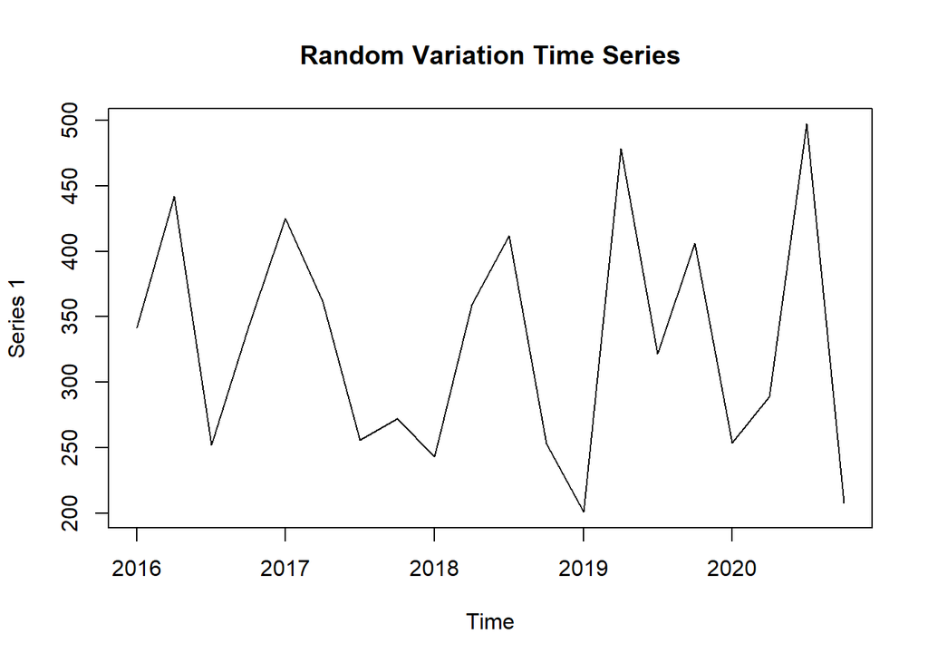

```r
plot(random1.ts, main = 'Random Variation Time Series')
```

#### 계절변동 시계열

##### 특정 주기마다 반복되는 패턴을 보이는 시계열 자료

예시: 강수량, 적설량, 아이스크림 판매 추이, 전력 소비량, 성숙한 플랫폼의 데일리 트래픽 등

```r
## 계절변동 시계열 (seasonality 계절)
season1.ts <- ts(data=season1 <- matrix(c(142, 242, 452, 528,
                                          125, 262, 456, 563,
                                          143, 269, 462, 518,
                                          121, 258, 472, 582,
                                          154, 249, 477, 555)), s=c(2016, 1), f=4)
season1.ts
```

```
##      Qtr1 Qtr2 Qtr3 Qtr4
## 2016  142  242  452  528
## 2017  125  262  456  563
## 2018  143  269  462  518
## 2019  121  258  472  582
## 2020  154  249  477  555
```

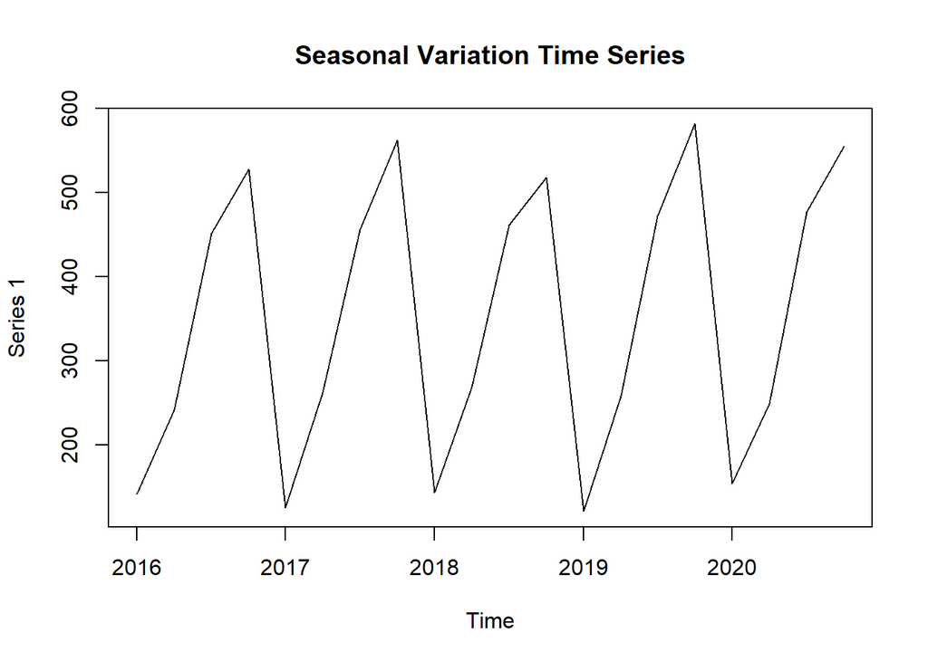

```r
plot(season1.ts, main = 'Seasonal Variation Time Series')
```

#### 추세변동 시계열

##### 시간에 따라 우상향 또는 우하향 패턴을 보이는 시계열 자료

예시: 물가 데이터, 희소 원자재 가격 데이터, 대부분의 주가지수 데이터

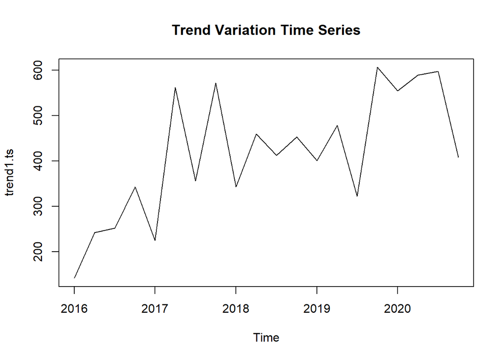

```r
## 추세변동 시계열

trend1.ts <- ts(trend1 <- c(142, 242, 252, 343,
                            225, 562, 356, 572,
                            343, 459, 412, 453,
                            401, 478, 322, 606,
                            554, 589, 597, 408), c(2016, 1), f=4)
plot(trend1.ts, main = 'Trend Variation Time Series')
```

주로 low point를 통해 추세를 파악

#### 계절적 추세변동 시계열

##### 계절변동 + 추세변동 시계열 자료로 실제로 접할 수 있는 많은 현상들이 이에 속함

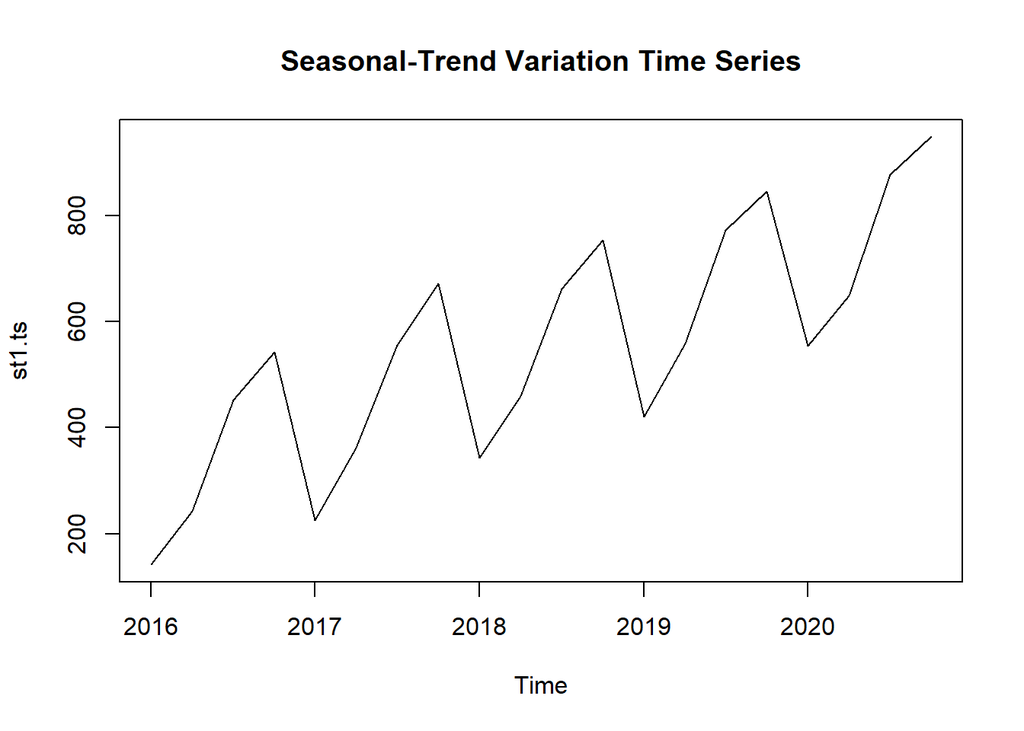

```r
## 계절적 추세변동 시계열
st1.ts <- ts(data = st1 <- c(142, 242, 452, 543,
                             225, 362, 556, 672,
                             343, 459, 662, 753,
                             421, 558, 772, 846,
                             554, 649, 877, 948), c(2016, 1), f=4)
plot(st1.ts, main = 'Seasonal-Trend Variation Time Series')
```